# Practical Machine Learning Assignment

## Prediction modelling

In this section we train several models on the training data in order to build a prediction model.

First I have build a classification model using Caret with the rpart method. Since the initial results with default settings resulted in an accuracy of only 0.4879, I have added tuning with repeated Cross Validation:

```r
mod_rpart <- train(classe ~ ., method = "rpart", data = TrainSet,tuneLength = 50,
                   metric = "Accuracy",
                   trControl = trainControl(method = "repeatedcv",
                                            number = 4,
                                            repeats = 5,
                                            summaryFunction = multiClassSummary,
                                            classProbs = TRUE))
pred_rpart <- predict(mod_rpart, TestSet)
confusionMatrix(pred_rpart, TestSet$classe)
```

```
## Confusion Matrix and Statistics
##
##           Reference
## Prediction    A    B    C    D    E
##          A 1645   16    4    8    3
##          B    7 1079   22    4   21
##          C    0   18  971    7   10
##          D   20   17   24  940   23
##          E    2    9    5    5 1025
##
## Overall Statistics
##
##                Accuracy : 0.9618
##                  95% CI : (0.9565, 0.9665)
##     No Information Rate : 0.2845
##     P-Value [Acc > NIR] : < 2.2e-16
##
##                   Kappa : 0.9516
##  Mcnemar's Test P-Value : 4.676e-07
##
## Statistics by Class:
##
##                      Class: A Class: B Class: C Class: D Class: E
## Sensitivity            0.9827   0.9473   0.9464   0.9751   0.9473
## Specificity            0.9926   0.9886   0.9928   0.9829   0.9956
## Pos Pred Value         0.9815   0.9523   0.9652   0.9180   0.9799
## Neg Pred Value         0.9931   0.9874   0.9887   0.9951   0.9882
## Prevalence             0.2845   0.1935   0.1743   0.1638   0.1839
## Detection Rate         0.2795   0.1833   0.1650   0.1597   0.1742
## Detection Prevalence   0.2848   0.1925   0.1709   0.1740   0.1777
## Balanced Accuracy      0.9877   0.9680   0.9696   0.9790   0.9715
```

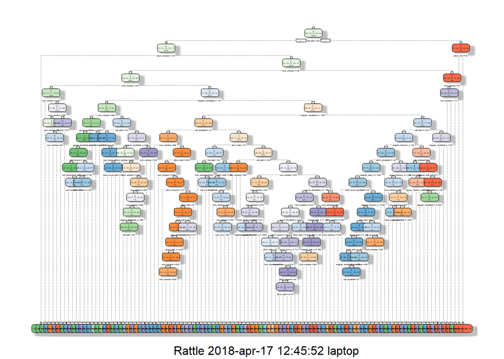

```r
fancyRpartPlot(mod_rpart$finalModel)
```

Second we build a similar model using rpart:

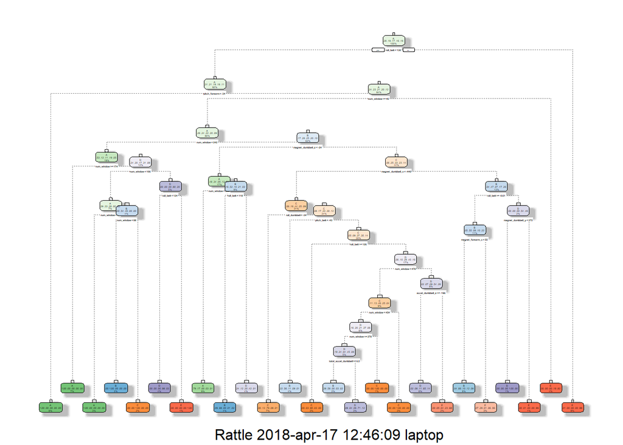

```r
# model fit
set.seed(12345)
modFitDecTree <- rpart(classe ~ ., data=TrainSet, method="class")
fancyRpartPlot(modFitDecTree)
```

```r
# prediction on Test dataset
predictDecTree <- predict(modFitDecTree, newdata=TestSet, type="class")
confMatDecTree <- confusionMatrix(predictDecTree, TestSet$classe)
confMatDecTree
```

```
## Confusion Matrix and Statistics
##
##           Reference
## Prediction    A    B    C    D    E
##          A 1400   77    4   20    6
##          B  178  873   65   70   46
##          C    0   62  843   30    2
##          D   78   71  105  747   75
##          E   18   56    9   97  953
##
## Overall Statistics
##
##                Accuracy : 0.8184
##                  95% CI : (0.8083, 0.8281)
##     No Information Rate : 0.2845
##     P-Value [Acc > NIR] : < 2.2e-16
##
##                   Kappa : 0.7711
##  Mcnemar's Test P-Value : < 2.2e-16
##
## Statistics by Class:
##
##                      Class: A Class: B Class: C Class: D Class: E
## Sensitivity            0.8363   0.7665   0.8216   0.7749   0.8808
## Specificity            0.9746   0.9244   0.9807   0.9331   0.9625
## Pos Pred Value         0.9290   0.7086   0.8997   0.6942   0.8411
## Neg Pred Value         0.9374   0.9428   0.9630   0.9549   0.9729
## Prevalence             0.2845   0.1935   0.1743   0.1638   0.1839
## Detection Rate         0.2379   0.1483   0.1432   0.1269   0.1619
## Detection Prevalence   0.2561   0.2093   0.1592   0.1828   0.1925
## Balanced Accuracy      0.9055   0.8454   0.9011   0.8540   0.9216
```

Third we fit a Random Forest model:

```r
mod_rf <- train(classe~., data = TrainSet, method = "rf")
pred_rf <- predict(mod_rf, TestSet)
confusionMatrix(pred_rf, TestSet$classe)
```

```
## Confusion Matrix and Statistics
##
##           Reference
## Prediction    A    B    C    D    E
##          A 1674    2    0    0    0
##          B    0 1137    0    0    2
##          C    0    0 1026    2    0
##          D    0    0    0  962    3
##          E    0    0    0    0 1077
##
## Overall Statistics
##
##                Accuracy : 0.9985
##                  95% CI : (0.9971, 0.9993)
##     No Information Rate : 0.2845
##     P-Value [Acc > NIR] : < 2.2e-16
##
##                   Kappa : 0.9981
##  Mcnemar's Test P-Value : NA
##
## Statistics by Class:
##
##                      Class: A Class: B Class: C Class: D Class: E
## Sensitivity            1.0000   0.9982   1.0000   0.9979   0.9954
## Specificity            0.9995   0.9996   0.9996   0.9994   1.0000
## Pos Pred Value         0.9988   0.9982   0.9981   0.9969   1.0000
## Neg Pred Value         1.0000   0.9996   1.0000   0.9996   0.9990
## Prevalence             0.2845   0.1935   0.1743   0.1638   0.1839
## Detection Rate         0.2845   0.1932   0.1743   0.1635   0.1830
## Detection Prevalence   0.2848   0.1935   0.1747   0.1640   0.1830
## Balanced Accuracy      0.9998   0.9989   0.9998   0.9987   0.9977
```

Fourth we fit a Boosted Trees model using gbm:

```r
mod_gbm <- train(classe ~ ., data = TrainSet, method = "gbm", verbose = FALSE)
pred_gbm <- predict(mod_gbm, TestSet)
confusionMatrix(pred_gbm, TestSet$classe)
```

```
## Confusion Matrix and Statistics
##
##           Reference
## Prediction    A    B    C    D    E
##          A 1669   14    0    0    0
##          B    5 1108    7    1    1
##          C    0   17 1015    9    0
##          D    0    0    4  954   11
##          E    0    0    0    0 1070
##
## Overall Statistics
##
##                Accuracy : 0.9883
##                  95% CI : (0.9852, 0.9909)
##     No Information Rate : 0.2845
##     P-Value [Acc > NIR] : < 2.2e-16
##
##                   Kappa : 0.9852
##  Mcnemar's Test P-Value : NA
##
## Statistics by Class:
##
##                      Class: A Class: B Class: C Class: D Class: E
## Sensitivity            0.9970   0.9728   0.9893   0.9896   0.9889
## Specificity            0.9967   0.9971   0.9946   0.9970   1.0000
## Pos Pred Value         0.9917   0.9875   0.9750   0.9845   1.0000
## Neg Pred Value         0.9988   0.9935   0.9977   0.9980   0.9975
## Prevalence             0.2845   0.1935   0.1743   0.1638   0.1839
## Detection Rate         0.2836   0.1883   0.1725   0.1621   0.1818
## Detection Prevalence   0.2860   0.1907   0.1769   0.1647   0.1818
## Balanced Accuracy      0.9968   0.9849   0.9920   0.9933   0.9945
```

## Prediction-model selection and predicting on the Test-data.

The Random Forest model gave the highest accuracy across all tested models. For that reason we select the Random Forest model for prediction on the Test-data.

```r
pred_testdata <- predict(mod_rf, testing)
pred_testdata
```

```
##  [1] B A B A A E D B A A B C B A E E A B B B
## Levels: A B C D E
```